# Signal Attenuation in Generative Data Synthesis

What Survives When a Known Data-Generating Process Is Resampled by a Tabular Generative Model

Aono Li

2026-09-15

# 1 Introduction

## 1.1 Motivation

Synthetic data has become a routine part of machine learning practice. It is used to protect privacy when real records cannot be shared, to enlarge training sets when real observations are scarce, and — increasingly — to supply the teaching and benchmarking datasets on which students and practitioners learn their craft. Kaggle’s monthly Playground Series, which supplies the primary dataset for this project, is generated in exactly this way: a deep generative model is trained on a real or semi-real source dataset and then used to produce a much larger synthetic version for competition. Hundreds of thousands of practitioners tune models against these datasets every month.

What is far less often examined is how faithful the synthetic copy actually is. A generative model is trained to reproduce the *distribution* of its source data, but predictive modeling depends on something narrower and more fragile: the *conditional* relationship between predictors and an outcome. A synthesis that reproduces every histogram perfectly could still distort every regression coefficient. If that happens, the synthetic dataset will quietly mislead anyone who uses it to ask which variables matter, or how much accuracy a given problem permits. This project asks whether that distortion occurs here, and if so, in which direction and by how much.

## 1.2 Key concepts and vocabulary

Because this report is written for readers who may be new to machine learning, the following terms are used throughout and are defined here.

**Supervised regression** is the task of predicting a continuous *outcome* variable from a set of *predictor* variables, using observations for which the outcome is already known. Here the outcome is a student’s exam score and the predictors are eleven measures of their study habits, lifestyle, and environment.

**Root mean squared error (RMSE)** measures how far predictions fall from the truth. If $y_i$ is the observed outcome and $\hat{y}_i$ the prediction for observation $i$, then

$$\text{RMSE} =
\sqrt{\frac{1}{n}\sum_{i=1}^{n}(y_i - \hat{y}_i)^2}.$$

It is expressed in the same units as the outcome, so an RMSE of 9 means that predictions are typically about nine exam points away from the true score. Lower is better. The related statistic $R^2$ reports the proportion of the outcome’s variance that a model explains, on a scale from 0 to 1.

**Training and testing sets.** A model that is evaluated on the same data used to fit it will flatter itself, because it can memorise rather than generalise. The standard remedy is to set aside a random portion of the data — the *testing set* — before any modeling begins, fit everything on the remaining *training set*, and look at the testing set exactly once, at the very end.

**Cross-validation** solves a related problem. Model builders often need to compare many candidate models before choosing one, but every look at the testing set risks contaminating it. In *k-fold cross-validation* the training set is split into $k$ equally sized folds; each fold in turn is held out while the model is fit on the other $k-1$, producing $k$ independent estimates of out-of-sample error that can be averaged. This gives an honest basis for comparison while leaving the testing set untouched.

**Hyperparameters and tuning.** Most models have settings that are not learned from the data but must be chosen in advance — the number of neighbours in a k-nearest neighbors model, the depth of a decision tree, the strength of a penalty term. These are *hyperparameters*, and the process of searching over candidate values and selecting the best by cross-validation is *tuning*.

**The bias–variance tradeoff** describes why more flexible models are not automatically better. A rigid model may systematically miss the true pattern (high *bias*); a highly flexible one may chase noise that happens to be present in the training sample and fail to generalise (high *variance*). The best model for a given dataset and sample size is the one that balances the two.

**Censoring** occurs when an outcome is recorded only within fixed bounds, so that values beyond those bounds are recorded at the boundary instead. As Section 2 shows, the exam scores in both datasets are censored at an upper limit of 100 and a lower limit of 19.599, producing a pile-up of observations at each end.

**Synthetic data and tabular generative models.** Synthetic data is generated by an algorithm rather than observed in the world. A *tabular generative model* such as CTGAN (Conditional Tabular Generative Adversarial Network) learns to produce rows that a discriminator network cannot distinguish from its training data. **Signal attenuation**, the phenomenon this report documents, refers to the systematic shrinkage of the association between predictors and outcome after such a synthesis.

## 1.3 An unusual experimental setup

The two datasets used here are both synthetic, and this should be stated plainly at the outset: no part of this analysis involves real student records, and no conclusion drawn here should be read as a finding about actual educational outcomes.

That limitation, however, creates an unusual opportunity. The source dataset was not observed but *constructed*: its documentation states that the exam score is derived from a weighted formula over the predictors. The competition dataset is understood to have been produced by training a deep tabular generative model on that source.

This identification should be stated as an assumption rather than a documented fact. Kaggle’s Playground Series is generated from a source dataset in this way by convention, and the two datasets here share an identical variable structure, identical outcome bounds, and — as Section 6.2 shows — regression coefficients that agree to within a few per cent. A competitor’s published write-up of this competition attributes the generation to CTGAN specifically. None of this is a statement from the competition organisers, however, so the analysis below is best read as comparing two datasets standing in a documented structural relationship, rather than as an audit of a generator whose training data is known with certainty. Section 6.6 returns to what this qualification does and does not affect. We therefore hold both ends of a generative pipeline — a data-generating process whose structure is known by construction, and the synthetic output of a model trained on it. Most studies of synthetic-data fidelity lack any ground truth and can only compare two opaque distributions to each other. Here, the ground truth is a formula, and departures from it are measurable.

## 1.4 Research questions

**Primary.** When a dataset produced by a known weighted formula is regenerated by a deep generative model, which properties are preserved and which are systematically distorted?

**Secondary.** At a matched sample size of 20,000 observations, does additional model complexity improve predictive accuracy, and how large is any gain over a simple linear baseline?

The primary modeling task that anchors both questions is a supervised regression problem: predict a student’s exam score from the eleven available predictors, and identify the model family best suited to doing so.

## 1.5 Data sources and citations

**Primary modeling dataset.**

> Kaggle. *Playground Series — Season 6, Episode 1: Predicting Student Test Scores.* Kaggle, 2026. https://www.kaggle.com/competitions/playground-series-s6e1

A synthetic dataset of 630,000 observations generated by a deep generative model. This project uses a stratified random sample of 20,000 rows, for reasons given in Section 3.1.

**Comparison arm.**

> Bedmutha, K. S. *Exam Score Prediction Dataset.* Kaggle, 2025. https://www.kaggle.com/datasets/kundanbedmutha/exam-score-prediction-dataset

A synthetic dataset of 20,000 observations in which the exam score is derived from a documented weighted formula over the predictors. It serves here as the ground-truth data-generating process against which the synthesis is compared.

**Codebook.** A codebook documenting every variable in both datasets — its type, its range or set of levels, and its meaning — is submitted alongside this report as `codebook.md`.

**External performance benchmarks.** Two publicly shared competition solutions are cited in Section 7 to place this project’s accuracy in context. No code from either is used in this project.

> Lim, Y. J. *First Loser (aka 4th place).* Kaggle, 2026. https://www.kaggle.com/competitions/playground-series-s6e1/writeups/first-loser-aka-4th-place

> lopure. *PS S6E1 | EDA + XGB — Last Competition Starter (as it is).* Kaggle, 2026. https://www.kaggle.com/code/lopure/ps-s6e1-eda-xgb-last-competition-starter-as-it-is

## 1.6 Roadmap

Section 2 explores both datasets, establishing three properties that govern everything that follows: the outcome is censored at both bounds, the relationship between the strongest predictor and the outcome is very close to linear, and five of the eleven predictors carry essentially no signal at all. Section 3 describes the sampling, train–test split, resampling scheme, and feature preprocessing. Section 4 fits and tunes five families of regression model, and Section 5 selects the best of them and evaluates it on data held out from the start. Section 6 then turns to the fidelity question that motivated the project, comparing the synthetic dataset against the source whose generating formula is known. Section 7 concludes.

# 2 Exploratory Data Analysis

This section examines the primary modeling dataset — the 20,000-row stratified sample of the competition data — and, where the comparison is informative, places it alongside the 20,000-row source dataset. Every figure and table is followed by its interpretation.

## 2.1 Distribution of the outcome

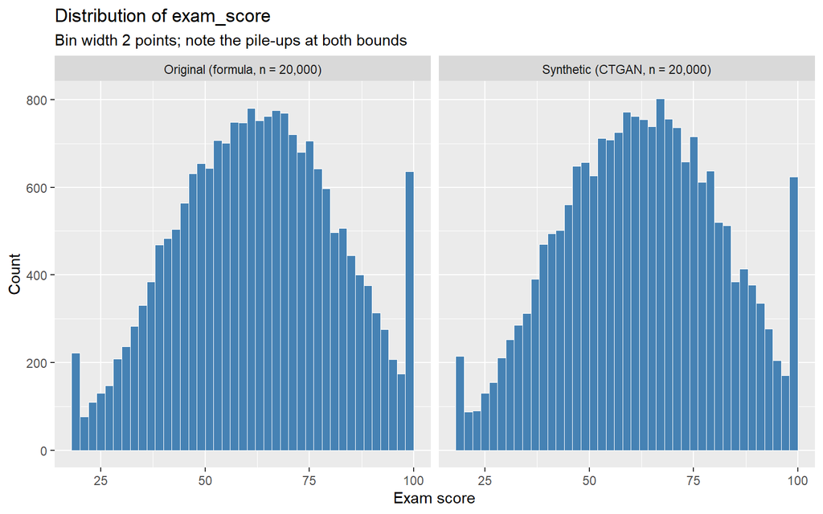

```r
eda$p_hist
```

The distribution of exam scores is broadly symmetric and centred near 62, but it is not a clean bell curve. Both panels show a conspicuous spike at the extreme right, where a substantial group of students sits at exactly 100. A smaller pile-up occurs at the left edge. This is the visual signature of **censoring**: the generating process produces values that would fall outside the interval $[19.599, 100]$ and then clips them to the boundary.

```r
knitr::kable(eda$censor_tbl,
             caption = "Observations at the bounds of the outcome variable")
```

Observations at the bounds of the outcome variable

| source | n | at_max | at_min | min | max | pct_at_max |
| --- | --- | --- | --- | --- | --- | --- |
| Synthetic | 20000 | 505 | 200 | 19.599 | 100 | 2.52 |
| Original | 20000 | 493 | 200 | 19.599 | 100 | 2.46 |

The counts make the pattern precise. In the synthetic sample, 505 students (2.52%) score exactly 100; in the source dataset, 493 (2.46%). At the lower bound, both datasets contain **exactly 200** observations at the value 19.599, and both share identical minima and maxima. The near-identical censoring behaviour is the first indication that the generative model reproduced the outcome’s boundary structure with high fidelity.

Censoring matters for what follows because it creates boundary-specific behaviour that an ordinary linear regression does not explicitly represent. Near the upper and lower limits, the relationship between the latent score and the recorded outcome is no longer linear because values beyond the limits are clipped to the boundary. This will become visible in the residual plots of Section 5, where the model shows systematic errors at the two censored limits.

## 2.2 Missing data

```r
knitr::kable(eda$missing_tbl,
             caption = "Missing values by variable and dataset")
```

Missing values by variable and dataset

| variable | Synthetic | Original |
| --- | --- | --- |
| age | 0 | 0 |
| gender | 0 | 0 |
| course | 0 | 0 |
| study_hours | 0 | 0 |
| class_attendance | 0 | 0 |
| internet_access | 0 | 0 |
| sleep_hours | 0 | 0 |
| sleep_quality | 0 | 0 |
| study_method | 0 | 0 |
| facility_rating | 0 | 0 |
| exam_difficulty | 0 | 0 |
| exam_score | 0 | 0 |

**Neither dataset contains a single missing value in any of its twelve columns.** No imputation step is therefore required anywhere in the modeling pipeline, and the recipe in Section 3.4 contains no `step_impute_*()` call.

This absence is worth pausing on rather than passing over. Real educational data is characteristically incomplete: students skip survey items, administrative records disagree, and attendance figures go unrecorded. A dataset of 20,000 student records with zero missingness in eleven behavioural and environmental variables is not a plausible real-world artifact. It is a property of synthetic generation, and it is the first of several respects in which these datasets are easier than the problem they represent.

## 2.3 Correlation structure among numeric variables

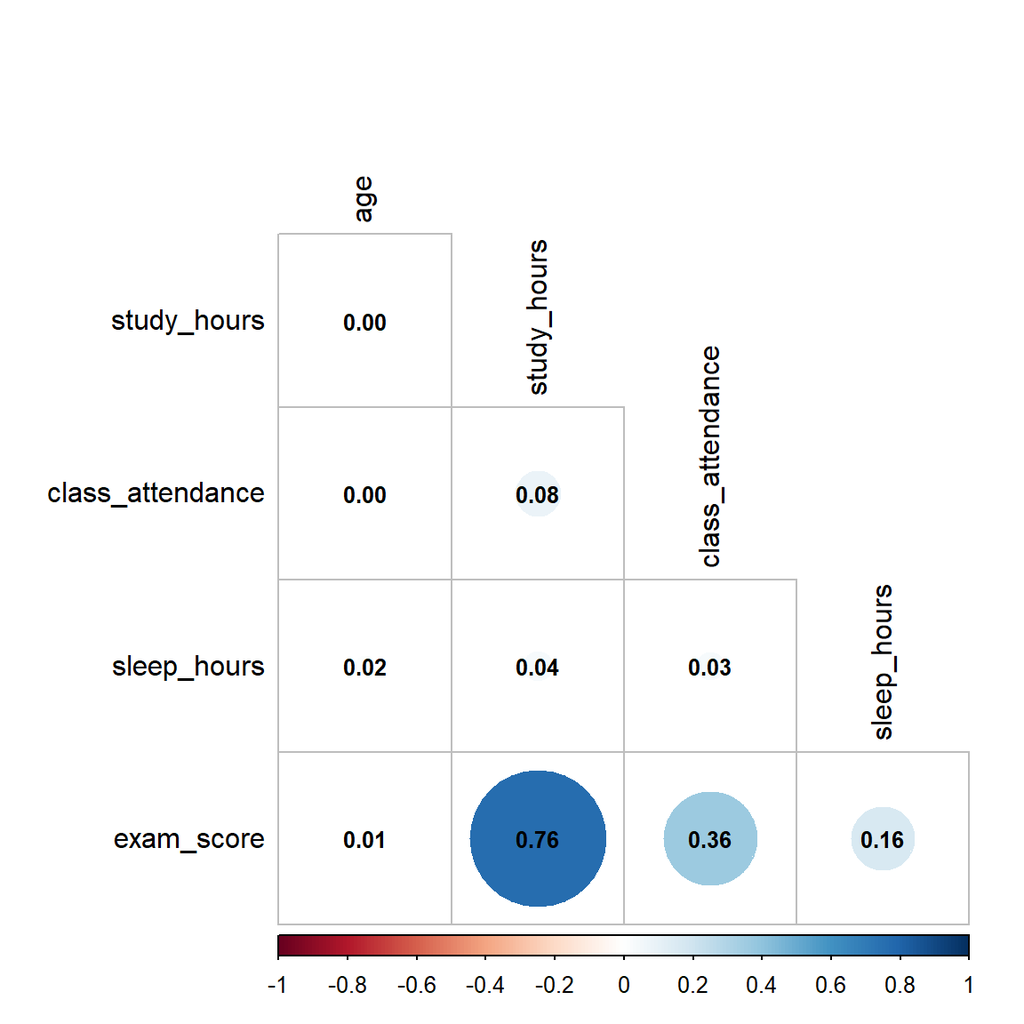

```r
corrplot(eda$num_mat, method = "circle", type = "lower",
         addCoef.col = "black", tl.col = "black", diag = FALSE, number.cex = .8)
```

Reading the bottom row first: `study_hours` is strongly associated with the outcome ($r = 0.76$), `class_attendance` moderately so ($r = 0.36$), `sleep_hours` weakly ($r = 0.16$), and `age` not at all ($r = 0.01$). A single predictor therefore accounts for the majority of the linear signal available in the numeric variables.

The rest of the matrix is more surprising, and more diagnostic. **The predictors are essentially uncorrelated with one another.** The largest inter-predictor correlation is 0.08, between `study_hours` and `class_attendance`; every other pair sits at 0.04 or below. In genuine educational data one would expect the opposite: conscientious students tend to both study more and attend more, so these two variables should be substantially correlated. Their near-independence here indicates that the predictors were drawn independently when the source dataset was constructed, rather than arising jointly from student behaviour.

This has a practical consequence and an interpretive one. Practically, multicollinearity is a non-issue, so no predictor need be dropped and coefficient estimates will be stable. Interpretively, it removes one of the main reasons flexible models usually outperform linear ones — there are no correlated predictor clusters or interaction structures for a tree ensemble to exploit.

## 2.4 The shape of the strongest relationship

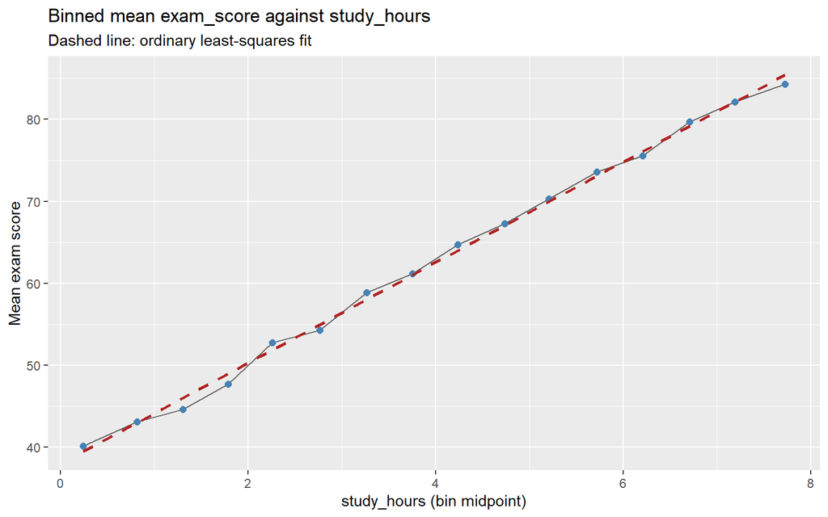

```r
eda$p_shape
```

Dividing `study_hours` into sixteen equal-width bins and plotting the mean exam score in each produces a line that is very nearly straight. Mean scores rise from 40.10 in the lowest bin to 84.28 in the highest — a span of 44.2 points across 7.5 hours, or roughly **5.9 points per additional hour of daily study** — and the rate of increase is close to constant across the entire range. The dashed ordinary least-squares fit tracks the binned means closely, with only slight departures near the lower end.

What is absent here is as important as what is present. There is no saturation at high study hours, no threshold below which studying does not help, and no curvature of any kind. A relationship of this shape is fully captured by a linear term. Flexible models such as random forests approximate smooth functions with piecewise-constant steps, which costs them accuracy precisely when the truth is a straight line. This figure is the strongest early evidence that a linear model will be difficult to beat.

## 2.5 Categorical predictors

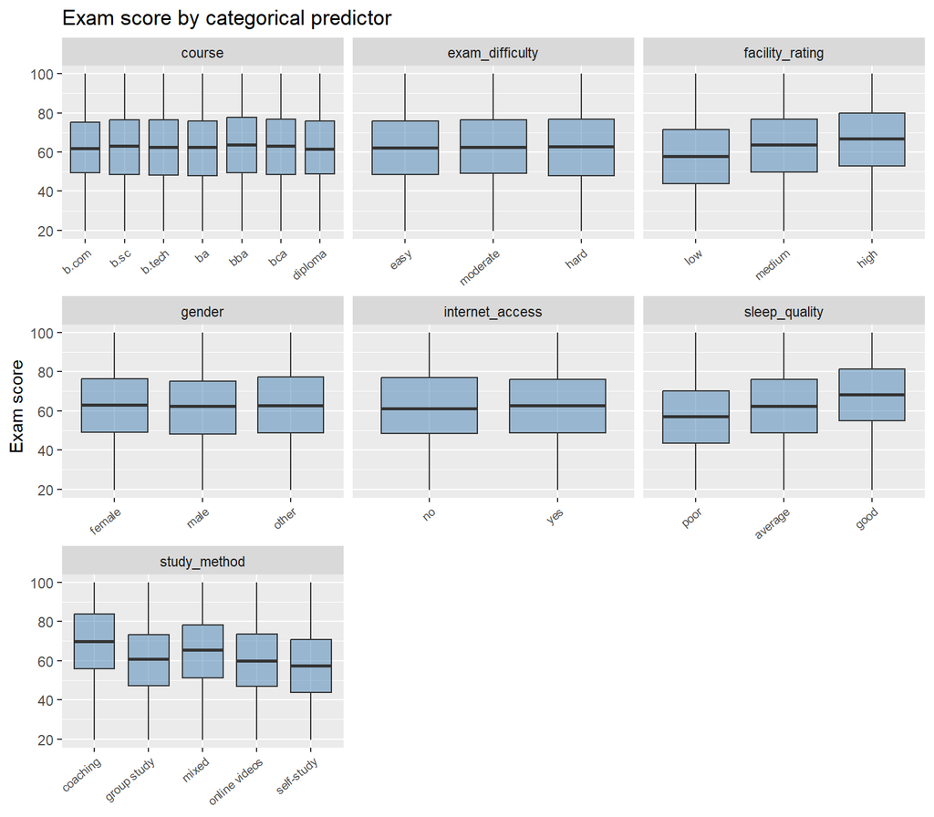

```r
eda$p_box
```

The seven categorical predictors fall cleanly into two groups. Three show clear ordered gradients: scores rise from `poor` to `good` sleep quality, from `low` to `high` facility rating, and across study methods from self-study up to coaching. The other four — `course`, `gender`, `internet_access`, and `exam_difficulty` — produce boxes that are visually indistinguishable from one another, with medians, quartiles, and whiskers essentially aligned.

The case of `exam_difficulty` deserves particular comment. Students who faced a `hard` paper score, on average, 62.60; those who faced an `easy` one score 62.26. The difference runs in the wrong direction and is negligible in size. Whatever else this dataset represents, the difficulty of the examination has no bearing on the score obtained.

## 2.6 Signal strength across all predictors

```r
knitr::kable(eda$signal_tbl,
             caption = "Signal strength of each predictor")
```

Signal strength of each predictor

| variable | statistic | measure | strength |
| --- | --- | --- | --- |
| study_method | 11.7246 | Group mean range (points) | 11.7246 |
| sleep_quality | 11.0617 | Group mean range (points) | 11.0617 |
| facility_rating | 8.7662 | Group mean range (points) | 8.7662 |
| course | 1.1542 | Group mean range (points) | 1.1542 |
| gender | 1.0064 | Group mean range (points) | 1.0064 |
| study_hours | 0.7640 | Pearson r | 0.7640 |
| class_attendance | 0.3620 | Pearson r | 0.3620 |
| exam_difficulty | 0.3427 | Group mean range (points) | 0.3427 |
| internet_access | 0.1802 | Group mean range (points) | 0.1802 |
| sleep_hours | 0.1632 | Pearson r | 0.1632 |
| age | 0.0100 | Pearson r | 0.0100 |

The table summarises each predictor’s association with the outcome: Pearson correlation for numeric variables, and the range between the highest and lowest group mean, in exam points, for categorical ones. The two measures are not on a common scale, so they should be read within rather than across type; for a rough comparison, recall from Section 2.4 that `study_hours` moves the mean outcome by 44.2 points across its range, far more than any categorical variable.

Ranked by effect, the categorical predictors separate sharply:

| Predictor | Group mean range (points) |
| --- | --- |
| `study_method` | 11.73 |
| `sleep_quality` | 11.06 |
| `facility_rating` | 8.77 |
| `course` | 1.16 |
| `gender` | 1.01 |
| `exam_difficulty` | 0.34 |
| `internet_access` | 0.18 |

There is roughly an eightfold gap between the third variable and the fourth. Taken together with the numeric correlations, **six of the eleven predictors carry usable signal and five carry essentially none**: `age`, `gender`, `course`, `internet_access`, and `exam_difficulty` each move the expected outcome by about one point or less, against an outcome standard deviation of nearly 19.

This finding sits awkwardly with the source dataset’s own documentation, which states that limited internet access and poor facilities create a disadvantage and that harder examination papers reduce achievable scores. Facilities do matter, and substantially. Internet access and exam difficulty do not appear to enter the generating process at all. The stated description of the data and the data itself disagree — a discrepancy returned to in Section 6.

## 2.7 Comparing the two datasets

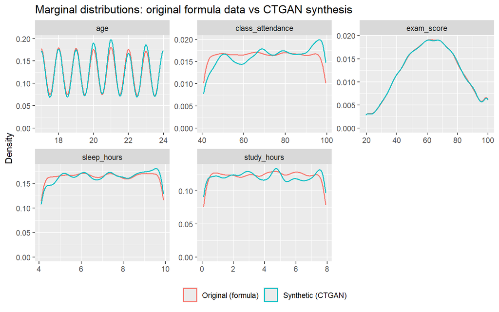

```r
eda$p_kde
```

```r
knitr::kable(eda$quant_tbl, caption = "Marginal distributions compared")
```

Marginal distributions compared

| variable | source | min | q25 | median | q75 | max | mean | sd |
| --- | --- | --- | --- | --- | --- | --- | --- | --- |
| age | Original (formula) | 17.000 | 18.00 | 20.00 | 22.00 | 24.00 | 20.473 | 2.284 |
| age | Synthetic (CTGAN) | 17.000 | 19.00 | 21.00 | 22.00 | 24.00 | 20.512 | 2.264 |
| class_attendance | Original (formula) | 40.600 | 55.10 | 69.90 | 85.00 | 99.40 | 70.017 | 17.282 |
| class_attendance | Synthetic (CTGAN) | 40.600 | 57.00 | 72.40 | 87.30 | 99.40 | 71.969 | 17.402 |
| exam_score | Original (formula) | 19.599 | 48.80 | 62.60 | 76.30 | 100.00 | 62.513 | 18.908 |
| exam_score | Synthetic (CTGAN) | 19.599 | 48.70 | 62.60 | 76.30 | 100.00 | 62.494 | 18.899 |
| sleep_hours | Original (formula) | 4.100 | 5.50 | 7.00 | 8.50 | 9.90 | 7.009 | 1.732 |
| sleep_hours | Synthetic (CTGAN) | 4.100 | 5.60 | 7.10 | 8.60 | 9.90 | 7.071 | 1.735 |
| study_hours | Original (formula) | 0.080 | 2.00 | 4.04 | 6.00 | 7.91 | 4.008 | 2.308 |
| study_hours | Synthetic (CTGAN) | 0.080 | 1.98 | 4.00 | 6.04 | 7.91 | 3.997 | 2.361 |

The source dataset’s predictor distributions are visibly **uniform**: `study_hours`, `class_attendance`, and `sleep_hours` all have flat densities across their ranges, and `age` is uniform over the integers 17 to 24. This is consistent with a constructed dataset in which predictors were drawn independently from uniform distributions and the outcome computed from them.

Against that flat baseline, the quality of the synthesis varies sharply by variable.

**The outcome is reproduced almost exactly.** The two `exam_score` densities lie on top of one another across the entire range, and the quartiles agree to within a tenth of a point: 48.70 / 62.60 / 76.30 in the synthetic sample against 48.80 / 62.60 / 76.30 in the source. Means differ by 0.02 and standard deviations by 0.01.

**The predictor marginals are reproduced less well.** Two distinct artifacts are visible. First, the synthetic densities *ripple*: where the source distributions are flat, the synthetic versions show regular waves, with spurious local modes in `study_hours` and `sleep_hours` and exaggerated peaks in the `age` spikes. These are characteristic mode artifacts of adversarial generators, which tend to concentrate probability mass at values they have learned to reproduce convincingly. Second, and more consequentially, `class_attendance` is **systematically shifted upward**: its median moves from 69.90 to 72.40 and its mean from 70.02 to 71.97, with the density plot showing a large accumulation of mass against the upper boundary near 100 and a corresponding depression around 55 to 65.

The summary, then, is not that the synthesis is faithful, but that its fidelity is uneven: nearly perfect for the outcome, good for most predictors, and measurably distorted for `class_attendance`. Whether the *conditional* relationships between predictors and outcome survived as well as the marginal distributions did is a separate question, and one the marginal plots cannot answer. Section 6 addresses it directly.

# 3 Data Splitting and Cross-Validation

## 3.1 Why a 20,000-row sample

The competition dataset contains 630,000 observations. Rather than use all of them, this project draws a stratified random sample of 20,000 rows, for two reasons.

The first is experimental design. The comparison arm — the source dataset — contains exactly 20,000 observations. Because model performance depends on sample size (a point Section 7 develops at length), comparing a model fit to 630,000 synthetic rows against one fit to 20,000 source rows would confound the effect of the synthesis with the effect of sample size. Matching the two at 20,000 removes that confound.

The second is computational. Tuning five model families over cross-validated grids requires fitting each candidate model many hundreds of times. At 20,000 observations this is feasible on a single machine within an hour; at 630,000 it is not.

```r
eda$quant_tbl %>%
  filter(variable == "exam_score") %>%
  knitr::kable(caption = "Outcome distribution preserved in the stratified sample")
```

Outcome distribution preserved in the stratified sample

| variable | source | min | q25 | median | q75 | max | mean | sd |
| --- | --- | --- | --- | --- | --- | --- | --- | --- |
| exam_score | Original (formula) | 19.599 | 48.8 | 62.6 | 76.3 | 100 | 62.513 | 18.908 |
| exam_score | Synthetic (CTGAN) | 19.599 | 48.7 | 62.6 | 76.3 | 100 | 62.494 | 18.899 |

The sample was drawn by dividing the full dataset into deciles of the outcome and taking 2,000 observations from each, so the distribution of `exam_score` in the sample matches that of the population it was drawn from.

## 3.2 The training–testing split

```r
split <- S$split
train <- S$train
test  <- S$test

c(training = nrow(train), testing = nrow(test))
```

```
## training  testing
##    15999     4001
```

The split and the resampling folds were created in `R/03_split_recipe.R` and are loaded here, rather than recreated, so that this report and the tuning in Section 4 refer to the same objects. The code that produced them is reproduced below.

```r
set.seed(131)

# Training-testing split, stratified on the outcome
split <- initial_split(syn20, prop = 0.80, strata = exam_score)
train <- training(split)
test  <- testing(split)

# Resampling folds, stratified on the outcome as well
folds <- vfold_cv(train, v = 5, strata = exam_score)
```

The sample is divided into a training set of 15,999 observations (80%) and a testing set of 4,001 (20%). The counts are not exactly 16,000 and 4,000 because the split is stratified: the data are divided into bands of the outcome and each band is split in proportion, so the remainders do not sum to a round number. Every choice made in the remainder of this report — which predictors to use, which models to fit, which hyperparameter values to adopt — is made using the training set alone. The testing set is examined exactly once, in Section 5, to obtain an honest estimate of how the selected model would perform on data it has never seen.

Stratifying on the outcome matters here. Under a simple random split, the training and testing sets would by chance contain slightly different proportions of high- and low-scoring students, and any difference in measured performance would partly reflect that imbalance rather than the model. Stratification instead splits within bands of the outcome, so that the distribution of exam scores is close to identical in both sets. With a censored outcome this matters more than usual: the observations piled up at 100 are the hardest to predict, and an unlucky split could concentrate them disproportionately in one set.

```r
bind_rows(
  train %>% summarise(set = "Training", n = n(), mean = mean(exam_score),
                      sd = sd(exam_score), q25 = quantile(exam_score, .25),
                      median = median(exam_score), q75 = quantile(exam_score, .75)),
  test  %>% summarise(set = "Testing",  n = n(), mean = mean(exam_score),
                      sd = sd(exam_score), q25 = quantile(exam_score, .25),
                      median = median(exam_score), q75 = quantile(exam_score, .75))
) %>%
  mutate(across(where(is.numeric), ~ round(.x, 3))) %>%
  knitr::kable(caption = "Outcome distribution in the training and testing sets")
```

Outcome distribution in the training and testing sets

| set | n | mean | sd | q25 | median | q75 |
| --- | --- | --- | --- | --- | --- | --- |
| Training | 15999 | 62.499 | 18.926 | 48.7 | 62.6 | 76.3 |
| Testing | 4001 | 62.474 | 18.794 | 48.7 | 62.6 | 76.3 |

The check confirms that stratification worked. Mean exam scores differ between the two sets by 0.03 points and standard deviations by 0.13, against an outcome that ranges across more than eighty points. All three quartiles — 48.7, 62.6 and 76.3 — are identical in both sets. Any difference in performance observed in Section 5 can therefore be attributed to the model rather than to an accident of the split.

## 3.3 k-fold cross-validation

```r
folds <- S$folds
folds
```

```
## #  5-fold cross-validation using stratification
## # A tibble: 5 × 2
##   splits               id
##   <list>               <chr>
## 1 <split [12797/3202]> Fold1
## 2 <split [12798/3201]> Fold2
## 3 <split [12799/3200]> Fold3
## 4 <split [12801/3198]> Fold4
## 5 <split [12801/3198]> Fold5
```

Choosing among five model families, each with its own hyperparameters, requires comparing many candidates — and each comparison needs an estimate of how the candidate would perform on unseen data. The testing set cannot supply these estimates, because using it repeatedly to make choices would turn it into a second training set and destroy its value as an impartial final check.

Five-fold cross-validation solves this using the training set alone. The 15,999 training observations are divided into five folds of roughly 3,200. A model is then fit five times: on the first pass, folds 2 through 5 are used for fitting and fold 1 is held out for evaluation; on the second pass, fold 2 is held out; and so on. Each observation is used for fitting four times and for evaluation once, and the five resulting RMSE values are averaged. The average is a far more stable estimate than any single held-out sample would provide, and the spread across folds gives a standard error that indicates how much confidence to place in small differences between models.

Five folds were chosen over the equally common ten for two reasons. The practical one is cost: tuning five model families over three-dimensional hyperparameter grids requires fitting several thousand models, and halving the number of folds halves that work. The statistical one is that the choice involves a tradeoff rather than a clear winner. With five folds each model is fit on 80% of the training data rather than 90%, so the resulting error estimate is slightly **pessimistic** — it describes a model trained on less data than the one eventually deployed. In exchange, the five estimates being averaged are less correlated with one another than ten would be, which makes their average less variable. Since every model here is compared on identical folds, any small pessimistic bias applies equally to all of them and cannot change the ranking.

The folds are stratified on the outcome for the same reason the initial split was: to prevent chance variation in the composition of folds from being mistaken for variation in model quality.

## 3.4 The recipe

```r
rec <- recipe(exam_score ~ ., data = train) %>%
  step_dummy(all_nominal_predictors()) %>%
  step_normalize(all_numeric_predictors())

rec
```

A `recipe` specifies the preprocessing applied to the predictors before any model sees them. Two steps are required here, and their order matters.

**`step_dummy()`** converts each categorical predictor into numeric indicator columns, since none of the five model families can consume a factor directly. A variable with $k$ levels becomes $k - 1$ indicators rather than $k$: one level is absorbed into the intercept as a reference category. This is deliberate and is the default. Creating all $k$ indicators — *one-hot* encoding — makes their sum identically equal to the intercept column, so the design matrix $X$ loses full column rank, $X^{\top}X$ becomes singular, and the ordinary least-squares coefficients are not uniquely defined. Tree ensembles tolerate one-hot encoding, but linear and penalised linear models do not, and a single recipe serves all five families here.

For the same reason, `sleep_quality`, `facility_rating`, and `exam_difficulty` are stored as ordinary factors with their levels placed in meaningful order, rather than as `ordered` factors. R applies polynomial contrasts to ordered factors by default, which would yield linear and quadratic trend terms in place of the interpretable indicator variables intended here.

**`step_normalize()`** centres each numeric predictor at zero and scales it to unit standard deviation. Two of the five model families are particularly sensitive to predictor scale. Elastic net applies a penalty to the magnitude of the coefficients, so predictors measured on larger scales would be penalised less simply by virtue of their units; `class_attendance` runs from 40 to 99 while `study_hours` runs from 0 to 8, and without scaling the penalty would fall almost entirely on the latter. K-nearest neighbors computes distances between observations, which are meaningless unless the dimensions are commensurable. Linear regression and the tree ensembles are unaffected by the transformation, so applying it uniformly costs nothing.

Normalisation follows dummy encoding so that the indicator columns are created before scaling is applied. All recipe steps are estimated from the training data only and then applied unchanged to the testing data, so that no information from the testing set can influence preprocessing.

```r
ncol(bake(prep(rec), new_data = NULL)) - 1
```

```
## [1] 23
```

After preprocessing, the eleven original predictors expand to 23 columns: the four numeric variables and nineteen indicators. The indicator counts follow the $k - 1$ rule described above — `gender` contributes two columns rather than three, `course` six rather than seven, `study_method` four rather than five — with the omitted level of each variable serving as its reference category.

# 4 Model Fitting

## 4.1 The five model families

Five families of model are fitted to the training data. All five are regression methods, and all are set to `mode = "regression"` in `parsnip`. This is worth stating explicitly because the course’s model catalogue also contains classification methods — logistic regression, linear and quadratic discriminant analysis — which predict class membership rather than a numeric value and are therefore inapplicable to a continuous outcome such as an exam score. Clustering methods and principal component analysis are likewise excluded: they are unsupervised, and this is a supervised prediction problem.

The five families were chosen to span the range from strong structural assumptions to none at all, because the exploratory analysis in Section 2 raised a specific question that only such a spread can answer. If the data-generating process really is close to linear and additive, as Section 2.4 suggested, the more flexible families should gain little and may lose something; if it is not, they should pull ahead decisively.

**Linear regression** serves as the baseline. It assumes the expected outcome is a weighted sum of the predictors, and it has no hyperparameters to tune. Its bias is high whenever the truth departs from that form, but its variance is very low: with 16,000 observations and 23 predictors, its coefficients are estimated with great precision. Given the near-straight relationship documented in Section 2.4, this is a serious contender rather than a straw man.

**Elastic net** is linear regression with a penalty added to the size of the coefficients. The penalty combines an $\ell_1$ term, which can shrink coefficients exactly to zero and thereby perform variable selection, and an $\ell_2$ term, which shrinks them smoothly toward zero without eliminating them. Two hyperparameters control it: `penalty` sets the overall strength of the shrinkage, and `mixture` sets the balance between the two terms, with 0 giving pure ridge regression and 1 pure lasso. This family is directly relevant here because Section 2.6 identified five predictors that carry essentially no signal. If discarding them helps, elastic net should find a penalty that does so and should beat unpenalised linear regression.

**K-nearest neighbors** makes no assumption about functional form at all. To predict a new observation it finds the `neighbors` training observations closest to it in predictor space and averages their outcomes. Small values of `neighbors` produce a highly flexible, high-variance fit; large values produce a smoother, higher-bias one. Its known weakness is dimensionality: in a 23-dimensional predictor space, even 16,000 points are sparse, and the nearest neighbours of a given observation may not be very near. It is included partly as a contrast — a purely local method set against globally structured ones — and partly because the curse of dimensionality is itself worth demonstrating.

**Random forest** builds many decision trees on bootstrap resamples of the training data and averages their predictions. At each split, only a random subset of `mtry` predictors is considered, which decorrelates the trees and makes their average more stable than any single tree. Three hyperparameters are tuned: `mtry`, the number of predictors offered at each split; `trees`, the number of trees in the ensemble; and `min_n`, the minimum number of observations a node must contain to be split further. Random forests capture interactions and nonlinearity automatically, without being told to look for them. Their structural cost is that a tree approximates any smooth function by a piecewise-constant staircase, which is inefficient when the truth is a straight line.

**Boosted trees** also build an ensemble, but sequentially rather than in parallel: each new tree is fitted to the residuals left by the ensemble so far, so the model concentrates its effort where it is currently doing worst. Three hyperparameters are tuned: `trees`, `tree_depth`, which caps how many splits deep any single tree may go and therefore the order of interaction the model can represent, and `learn_rate`, which scales each tree’s contribution. A low learning rate with many trees usually generalises better than a high rate with few. Gradient boosting is generally the strongest performer on tabular data of this kind, and it is the family the leading competition solutions relied on.

Every model is fitted to the same five folds of the training set, using the recipe from Section 3.4, and evaluated by the same metric. Each family with hyperparameters is tuned by searching a grid of candidate values and selecting the combination with the lowest cross-validated RMSE. All tuning results were computed in `R/04_tune_models.R` and stored; this report reads them rather than recomputing them.

For the two tree ensembles, a space-filling design of 25 candidate combinations is used in place of an exhaustive grid. With three hyperparameters to vary, an exhaustive grid at four levels each would require 64 combinations, most of them clustered along the axes of the space. A space-filling design spreads the same search effort more evenly through the interior of the three-dimensional region, which gives better coverage per model fitted.

## 4.2 Linear regression

```r
collect_metrics(tuning$lm) %>%
  mutate(across(where(is.numeric), ~ round(.x, 4))) %>%
  knitr::kable(caption = "Cross-validated performance of the linear baseline")
```

Cross-validated performance of the linear baseline

| .metric | .estimator | mean | n | std_err | .config |
| --- | --- | --- | --- | --- | --- |
| mae | standard | 7.0835 | 5 | 0.0510 | pre0_mod0_post0 |
| rmse | standard | 8.8534 | 5 | 0.0619 | pre0_mod0_post0 |
| rsq | standard | 0.7812 | 5 | 0.0025 | pre0_mod0_post0 |

With no hyperparameters, linear regression is fitted once per fold and requires no tuning. It establishes the standard the other four families must beat.

## 4.3 Elastic net

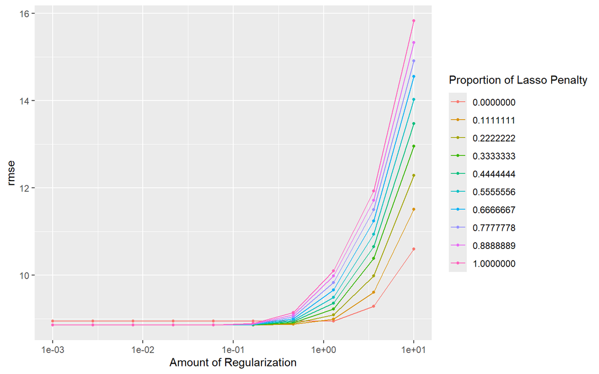

```r
autoplot(tuning$en, metric = "rmse")
```

```r
select_best(tuning$en, metric = "rmse") %>%
  knitr::kable(caption = "Selected elastic net hyperparameters")
```

Selected elastic net hyperparameters

| penalty | mixture | .config |
| --- | --- | --- |
| 0.001 | 1 | pre0_mod010_post0 |

The tuned model selects `penalty` = 0.001 with `mixture` = 1. Both values are worth reading carefully. A `mixture` of 1 is pure lasso, the variant that can eliminate predictors outright; a `penalty` of 0.001 is the **smallest value in the search grid**, meaning the penalty is as close to zero as the tuning was permitted to make it. In other words, the elastic net was offered the opportunity to shrink or discard predictors and declined it: the selected model is ordinary least squares in all but name, and its cross-validated RMSE is identical to the linear baseline to four decimal places.

This is a substantive result rather than a null one. Section 2.6 identified five predictors carrying no signal, and regularisation is the standard remedy for exactly that situation. That it provides no benefit here reflects the sample size: with 15,999 observations and 23 predictors, the variance introduced by estimating a handful of coefficients that are truly zero is negligible, so there is nothing for shrinkage to recover. The bias it would introduce on the eleven genuine coefficients outweighs any variance it could save.

## 4.4 K-nearest neighbors

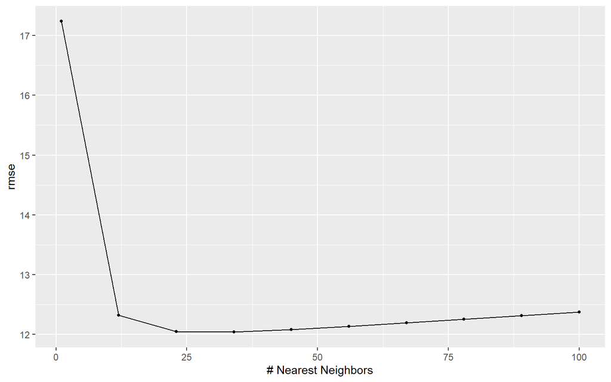

```r
autoplot(tuning$knn, metric = "rmse")
```

```r
select_best(tuning$knn, metric = "rmse") %>%
  knitr::kable(caption = "Selected number of neighbours")
```

Selected number of neighbours

| neighbors | .config |
| --- | --- |
| 34 | pre0_mod04_post0 |

The optimal neighbourhood size is 34. The tuning curve has the characteristic shape: very small neighbourhoods produce high-variance predictions that track noise in individual training points, and very large ones smooth away real structure, with a minimum in between.

That minimum, however, is poor in absolute terms, as Section 4.7 shows. The reason is dimensionality. After dummy encoding there are 23 predictors, and in a 23-dimensional space even 12,800 training points are extremely sparse: the 34 “nearest” neighbours of a given observation are not, in any meaningful sense, near it. Distance-based methods rely on the premise that nearby points have similar outcomes, and that premise weakens rapidly as dimensions accumulate.

## 4.5 Random forest

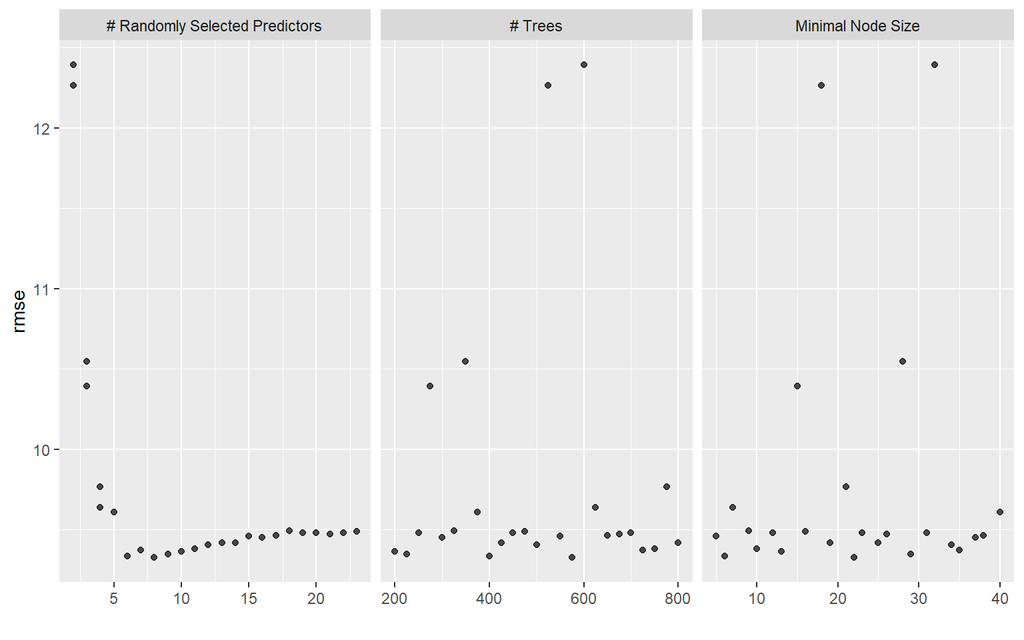

```r
autoplot(tuning$rf, metric = "rmse")
```

```r
select_best(tuning$rf, metric = "rmse") %>%
  knitr::kable(caption = "Selected random forest hyperparameters")
```

Selected random forest hyperparameters

| mtry | trees | min_n | .config |
| --- | --- | --- | --- |
| 8 | 575 | 22 | pre0_mod10_post0 |

The selected forest uses `mtry` = 8 predictors per split, `trees` = 575, and a minimum node size of 22. The value of `mtry` sits well below the 23 available, confirming that decorrelating the trees helps; a forest that considered every predictor at every split would be bagging rather than a random forest, and would produce more highly correlated trees whose average is less stable.

## 4.6 Boosted tree

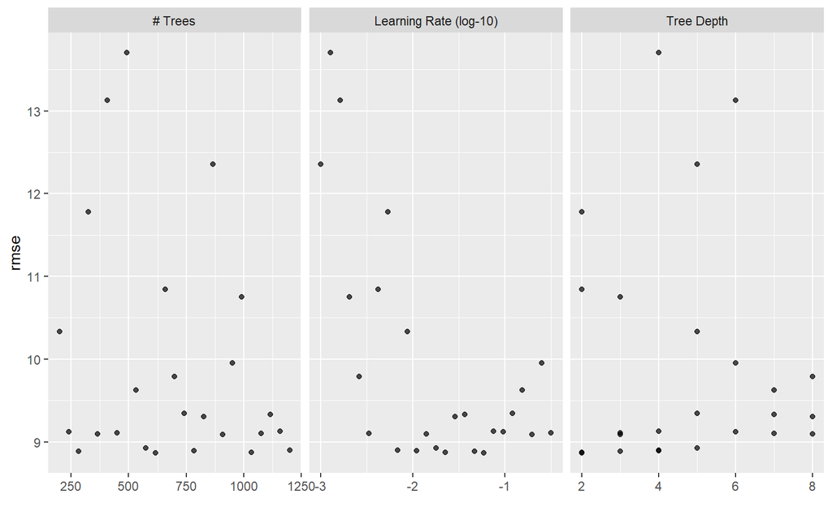

```r
autoplot(tuning$bt, metric = "rmse")
```

```r
select_best(tuning$bt, metric = "rmse") %>%
  knitr::kable(caption = "Selected boosted tree hyperparameters")
```

Selected boosted tree hyperparameters

| trees | tree_depth | learn_rate | .config |
| --- | --- | --- | --- |
| 616 | 2 | 0.0589975 | pre0_mod11_post0 |

The selected configuration uses 616 trees at a learning rate of 0.059 — a moderate rate with a moderate number of trees, the usual well-behaved combination — and a `tree_depth` of **2**, which is the smallest depth the search grid allowed.

That last value deserves emphasis. Tree depth controls the highest order of interaction a boosted model can represent: a depth of 1 fits a purely additive model, depth 2 permits two-way interactions, and so on. The tuning selected the shallowest trees available, and did so despite having depths up to 8 on offer. The model is telling us that interaction structure, which is the principal advantage boosting holds over an additive model, is not present in these data in any quantity worth capturing. This corroborates Section 2.3, where the predictors proved almost entirely uncorrelated with one another, and Section 2.4, where the dominant predictor’s relationship with the outcome proved almost perfectly straight.

## 4.7 Cross-validated performance

```r
tuning$summary_tbl %>%
  mutate(`Difference from best` = round(mean - min(mean), 4),
         `In standard errors`   = round((mean - min(mean)) / std_err, 1)) %>%
  knitr::kable(caption = "Cross-validated RMSE across the five model families")
```

Cross-validated RMSE across the five model families

| model | mean | std_err | n | Difference from best | In standard errors |
| --- | --- | --- | --- | --- | --- |
| Elastic net | 8.8534 | 0.0623 | 5 | 0.0000 | 0.0 |
| Linear regression | 8.8534 | 0.0619 | 5 | 0.0000 | 0.0 |
| Boosted tree | 8.8626 | 0.0558 | 5 | 0.0092 | 0.2 |
| Random forest | 9.3250 | 0.0629 | 5 | 0.4716 | 7.5 |
| K-nearest neighbors | 12.0347 | 0.0398 | 5 | 3.1813 | 79.9 |

The five families separate into three clear tiers.

**The top tier is a three-way tie.** Linear regression and elastic net achieve identical cross-validated RMSE of 8.8534 — unsurprisingly, since the tuned elastic net *is* ordinary least squares. The boosted tree reaches 8.8626, which is 0.009 worse, or about one sixth of a standard error. No meaningful distinction can be drawn between these three: the gap is an order of magnitude smaller than the uncertainty in any of the estimates.

Taken together, the ranking inverts the intuition that more flexible models perform better. The two most flexible families here occupy the bottom two positions, and the least flexible family shares first place. The reason is not that flexibility is bad, but that flexibility is only worth its variance cost when there is structure to find. Sections 2.3, 2.4 and 4.6 all point to the same conclusion: in this dataset, there is very little.

# 5 Model Selection and Test-Set Performance

> All model selection and test-set evaluation reported in this section is performed on the primary dataset. The source dataset enters only as a comparison arm in the fidelity analysis that follows.

## 5.1 Selecting the best model

Section 4.7 left three families statistically indistinguishable at the top. The lowest cross-validated RMSE belongs to the elastic net, and that is the model carried forward. Its selected configuration, however, makes the choice less consequential than it appears.

```r
final$best_par %>% knitr::kable(caption = "Configuration of the selected model")
```

Configuration of the selected model

| penalty | mixture | .config |
| --- | --- | --- |
| 0.001 | 1 | pre0_mod010_post0 |

The tuned elastic net uses a penalty of 0.001, the smallest value the search grid contained. At that strength the shrinkage is numerically negligible, and the fitted model coincides with ordinary least squares — which is why its cross-validated RMSE matches the linear baseline to four decimal places. The model carried into the testing set is, in substance, a linear regression. Nothing in the conclusions below would change had the linear baseline been selected instead.

Only this one model is used to predict the testing set. The other four are not, and their testing performance is not computed or reported. Fitting several candidates to held-out data and then reporting the best of them would reintroduce exactly the selection bias that holding data out is meant to prevent.

## 5.2 Performance on the testing set

```r
final$test_metrics %>%
  knitr::kable(caption = "Performance of the selected model on the testing set")
```

Performance of the selected model on the testing set

| .metric | .estimator | .estimate |
| --- | --- | --- |
| rmse | standard | 8.7398 |
| rsq | standard | 0.7841 |
| mae | standard | 6.9905 |

On the 4,001 observations withheld at the outset, the model achieves an RMSE of 8.740, an $R^2$ of 0.784, and a mean absolute error of 6.991. Predictions are typically within about seven exam points of the truth, and the model accounts for roughly 78% of the variation in exam scores.

The ratio of RMSE to MAE is 1.250. For normally distributed errors this ratio is $\sqrt{\pi/2} \approx 1.253$, so the observed ratio is consistent with a roughly normal bulk error distribution. The ratio alone, however, is not a diagnostic of normality; the residual plots below provide the more informative check and show that the clearest departures are concentrated at the censored boundaries.

```r
tibble(
  Quantity = c("Cross-validated RMSE (5 folds)", "Testing RMSE", "Difference"),
  Value = round(c(final$cv_rmse,
                  final$test_metrics$.estimate[final$test_metrics$.metric == "rmse"],
                  final$test_metrics$.estimate[final$test_metrics$.metric == "rmse"] - final$cv_rmse), 4)
) %>% knitr::kable(caption = "Cross-validated and testing error compared")
```

Cross-validated and testing error compared

| Quantity | Value |
| --- | --- |
| Cross-validated RMSE (5 folds) | 8.8534 |
| Testing RMSE | 8.7398 |
| Difference | -0.1136 |

The testing RMSE is 0.114 **lower** than the cross-validated estimate. Test error coming in better than expected is less alarming than the reverse, and two things explain it. The first is structural: each cross-validation fit used four fifths of the training set, or about 12,800 observations, whereas the final model was fitted to all 15,999. More training data yields a slightly better model, so the cross-validated figure is mildly pessimistic by construction — as anticipated in Section 3.3. The second is sampling variation: the difference amounts to roughly 1.8 cross-validation standard errors, which is unremarkable for a single held-out sample of 4,001 observations.

What matters for the project’s argument is that the two figures agree closely. There is no sign of overfitting, which is what one would expect given that the selected model has 23 coefficients estimated from 15,999 observations and no effective penalty.

## 5.3 Residual diagnostics

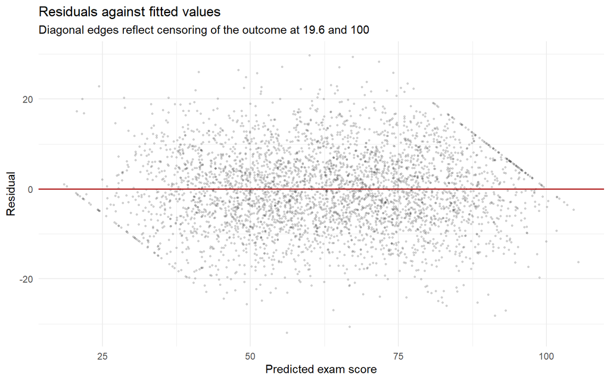

```r
final$p_resid
```

The residuals show no curvature, no funnelling, and no drift across the range of fitted values — the linear specification is not systematically wrong anywhere in the interior. What the plot does show, unmistakably, are two sharp diagonal boundaries at the upper right and lower left. These are the censoring of the outcome made visible. An observation recorded at exactly 100 has residual $100 - \hat{y}$, which traces a line of slope $-1$ against $\hat{y}$; the same holds at the lower bound with the opposite sign. No observation can lie beyond those lines, because no outcome beyond the bounds exists in the data.

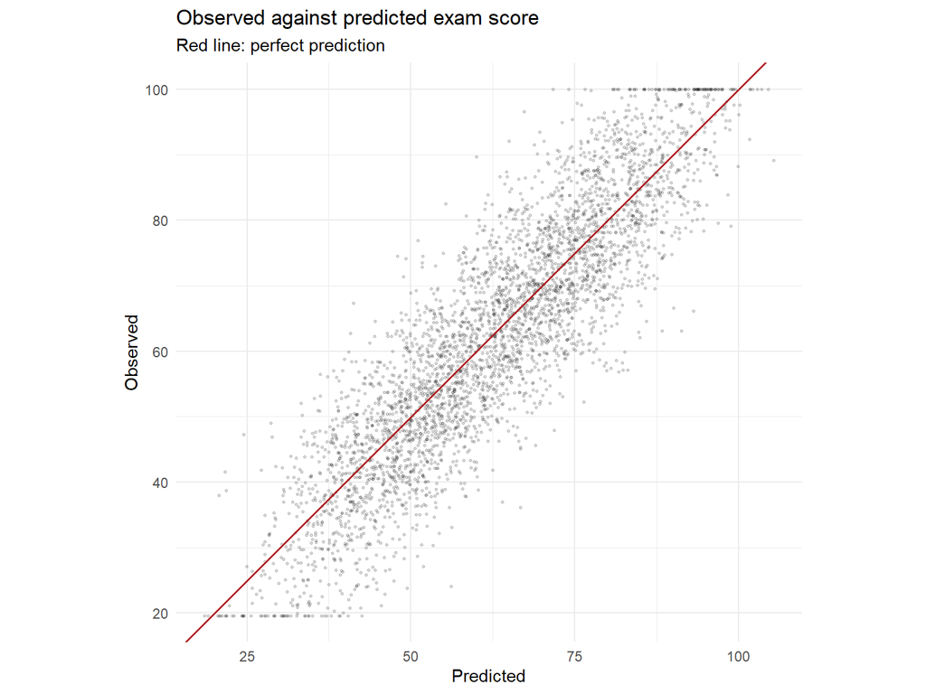

```r
final$p_obs_pred
```

The same structure appears in the observed-against-predicted plot as two horizontal bands of points at $y = 100$ and $y \approx 19.6$, stretching across a wide range of predicted values. Elsewhere the cloud is centred on the diagonal with no visible bias.

```r
final$preds %>%
  mutate(.resid = exam_score - .pred,
         Region = case_when(exam_score == 100 ~ "At upper bound (100)",
                            exam_score <= 20  ~ "At lower bound (19.6)",
                            TRUE              ~ "Interior")) %>%
  group_by(Region) %>%
  summarise(n = n(),
            `Mean residual` = round(mean(.resid), 3),
            `SD of residual` = round(sd(.resid), 3), .groups = "drop") %>%
  knitr::kable(caption = "Residuals by region of the outcome")
```

Residuals by region of the outcome

| Region | n | Mean residual | SD of residual |
| --- | --- | --- | --- |
| At lower bound (19.6) | 49 | -9.712 | 6.304 |
| At upper bound (100) | 89 | 8.309 | 6.480 |
| Interior | 3863 | -0.442 | 8.643 |

Quantifying the effect: across the 3,863 interior observations the mean residual is $-0.44$, close to zero as it should be. At the upper bound the mean residual is $+8.31$, and at the lower bound $-9.71$. The model systematically under-predicts students who scored 100 and over-predicts those at the floor.

This is not a failure of the model so much as a consequence of what the outcome measures. A student recorded at 100 may have had a latent score of 105 or 115; the recording process cannot distinguish them. A linear model fitted to the clipped outcomes learns the conditional mean of the observed, censored response rather than the latent uncensored score, so it does not explicitly account for the censoring mechanism at the boundaries. The affected observations are a small minority — 89 at the ceiling and 49 at the floor out of 4,001, about 3.4% combined — but they reveal a systematic boundary pattern that the ordinary linear specification does not model directly. A censored-regression specification could address this mechanism explicitly and is therefore a natural extension considered in Section 7.4.

## 5.4 Variable importance

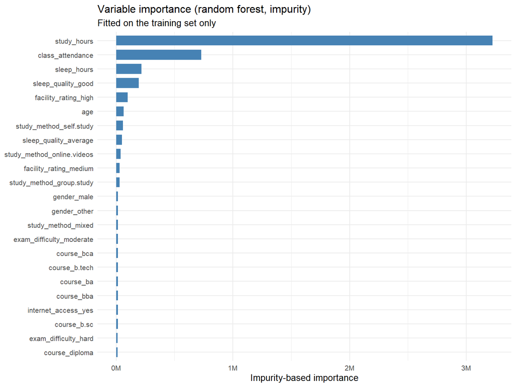

```r
final$p_vip
```

```r
final$vip_tbl %>% head(12) %>%
  knitr::kable(caption = "Twelve most important predictors (random forest, impurity)")
```

Twelve most important predictors (random forest, impurity)

| Variable | Importance |
| --- | --- |
| study_hours | 3224588.5 |
| class_attendance | 727725.3 |
| sleep_hours | 217212.4 |
| sleep_quality_good | 192347.9 |
| facility_rating_high | 98889.4 |
| age | 65162.9 |
| study_method_self.study | 57597.3 |
| sleep_quality_average | 49747.3 |
| study_method_online.videos | 37683.9 |
| facility_rating_medium | 30249.4 |
| study_method_group.study | 29978.9 |
| gender_male | 15583.1 |

Variable importance is computed from the tuned random forest fitted to the training set. The random forest is used here rather than the selected model because impurity-based importance is a property of tree ensembles; no testing data is involved, so this does not conflict with the single model used in Section 5.2.

The ranking broadly confirms the exploratory analysis. `study_hours` dominates overwhelmingly, at more than four times the importance of `class_attendance` in second place, which in turn leads `sleep_hours` and `sleep_quality_good`. The signal-carrying predictors identified in Section 2.6 occupy the top of the table and the null ones cluster at the bottom.

Two entries do not fit, however, and both are instructive.

**`age` ranks sixth** — ahead of every indicator for `study_method` — yet Section 2.6 measured its correlation with the outcome at 0.010 and Section 6 estimated its regression coefficient at 0.002. By every direct measure it is noise. And **`sleep_hours` ranks third**, ahead of `sleep_quality`, even though the latter explains more than twice as much of the outcome’s variance.

```r
final$imp_cmp %>%
  knitr::kable(caption = "Importance rank against explanatory power and number of distinct values")
```

Importance rank against explanatory power and number of distinct values

| source_var | n_distinct | single_r2 | importance_rank |
| --- | --- | --- | --- |
| study_hours | 784 | 0.5837 | 1 |
| class_attendance | 589 | 0.1311 | 2 |
| sleep_hours | 59 | 0.0266 | 3 |
| sleep_quality | 3 | 0.0580 | 4 |
| facility_rating | 3 | 0.0361 | 5 |
| age | 8 | 0.0001 | 6 |
| study_method | 5 | 0.0500 | 7 |
| gender | 3 | 0.0005 | 12 |
| exam_difficulty | 3 | 0.0000 | 15 |
| course | 7 | 0.0001 | 16 |
| internet_access | 2 | 0.0000 | 20 |

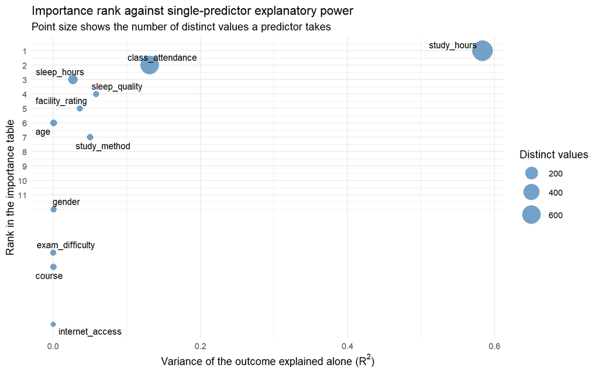

```r
final$p_imp_signal
```

To compare the predictors on one scale, the table reports the proportion of outcome variance each explains on its own — $r^2$ for numeric predictors and $\eta^2$ for categorical ones. On that measure, `sleep_quality` explains 5.8% of the outcome’s variance against `sleep_hours`’ 2.7%, and `study_method` explains 5.0% against `age`’s 0.01%. Both pairs are ranked the wrong way round by importance.

What the two displaced variables have in common is that they take many values. `sleep_hours` takes 59 distinct values in this sample and `age` takes 8, while every categorical predictor has been reduced to indicators taking exactly two. Impurity-based importance accumulates the reduction in node impurity a variable achieves across all splits, and a variable with more distinct values offers more places to split. It therefore accumulates a larger total simply by being available more often, even when no individual split captures anything real. This bias is well documented for impurity-based measures.

The effect should not be overstated. Across all eleven predictors the importance ranking correlates with genuine explanatory power at a Spearman coefficient of 0.858, against 0.707 for the number of distinct values — the ranking is mostly tracking signal, not cardinality. But “mostly” is doing work in that sentence. The two exceptions are not at the margins of the table; one of them is a variable with no relationship to the outcome whatsoever, sitting in sixth place out of twenty-three.

The practical lesson is that importance rankings are evidence, not verdicts, and they should be read alongside direct measures rather than in place of them. Had this project relied on the importance plot alone, `age` would have been reported as a meaningful determinant of exam performance. The exploratory analysis in Section 2 and the coefficient estimates in Section 6 both say otherwise, and they are right. A permutation-based importance measure, which is not subject to the same cardinality bias, would be the natural cross-check.

# 6 Fidelity Analysis

Sections 2 through 5 treated the competition dataset as the object of study. This section turns to the question that motivated the project: what did the generative model preserve, and what did it change? Because the source dataset’s outcome is constructed from a weighted formula over the predictors, its conditional structure is a ground truth against which the synthesis can be measured. Both datasets contain exactly 20,000 observations, so nothing in what follows is attributable to a difference in sample size.

The comparison uses ordinary least squares fitted separately to each dataset under an identical recipe. Because predictors are standardised, each coefficient reports the change in exam score associated with a one-standard-deviation change in that predictor, and the two sets of coefficients are directly comparable. No testing data is involved anywhere in this section, and no model selection depends on it.

## 6.1 Marginal distributions

Section 2.7 established that the outcome’s marginal distribution survived the synthesis almost perfectly — quartiles agreeing to within a tenth of a point — while the numeric predictors fared less well, with spurious ripples appearing on distributions that were uniform in the source and `class_attendance` shifting upward by roughly two points.

The categorical predictors show the same unevenness, and more sharply.

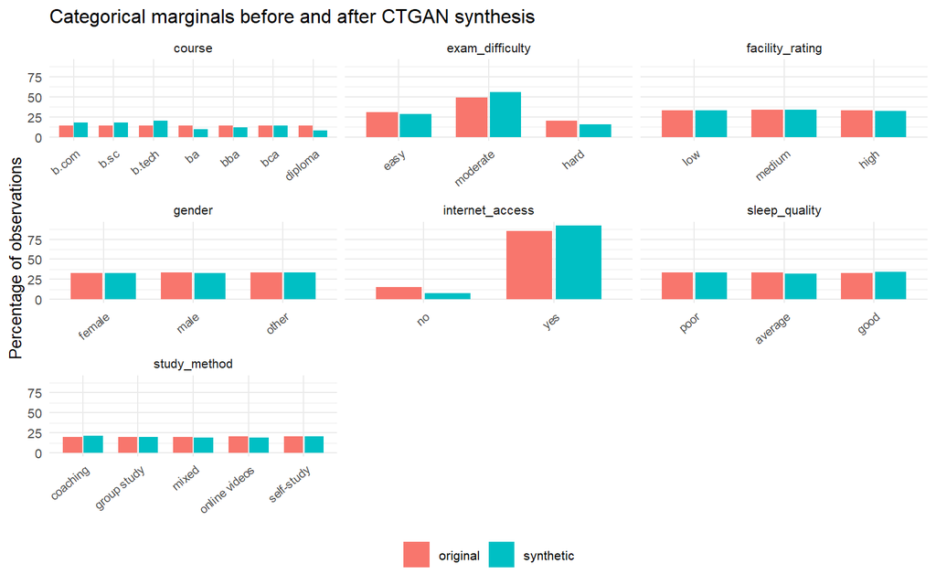

```r
fid$p_cat
```

```r
knitr::kable(fid$tvd,
             caption = "Total variation distance between the two datasets, in percentage points")
```

Total variation distance between the two datasets, in percentage points

| variable | tvd |
| --- | --- |
| course | 13.97 |
| internet_access | 7.20 |
| exam_difficulty | 6.39 |
| study_method | 1.41 |
| sleep_quality | 1.34 |
| facility_rating | 0.53 |
| gender | 0.30 |

Total variation distance summarises how far two categorical distributions are apart: it is half the sum of the absolute differences in the proportion assigned to each level, so a value of 0 means the distributions are identical and a value of 14 means that fourteen per cent of the probability mass would have to be moved to reconcile them.

Three variables are reproduced almost exactly — `study_method`, `sleep_quality` and `facility_rating` are all uniform across their levels in the source and remain so in the synthesis. `gender` likewise survives unchanged. But `course`, which is very nearly uniform in the source with each of its seven programmes holding about fourteen per cent of students, becomes badly lopsided in the synthesis, ranging from under eight per cent to over twenty. `internet_access` and `exam_difficulty` are distorted substantially as well.

## 6.2 Conditional relationships

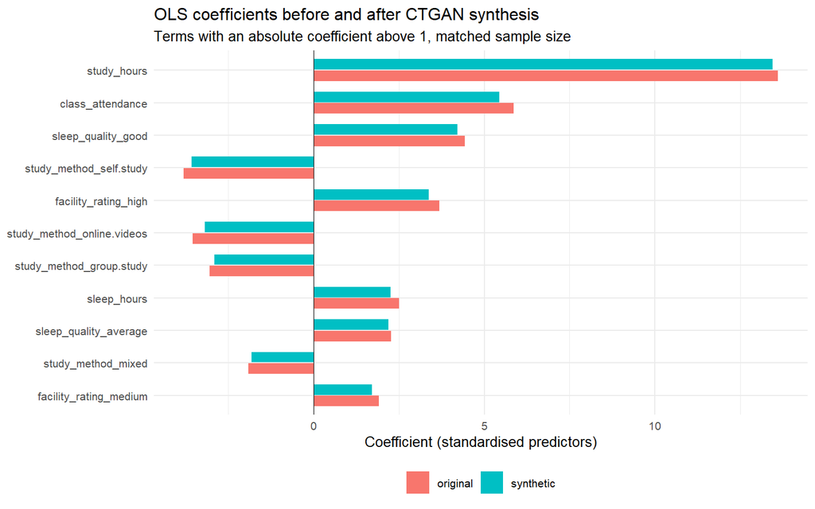

```r
fid$p_coef
```

```r
fid$strong %>%
  mutate(across(where(is.numeric), ~ round(.x, 4))) %>%
  knitr::kable(caption = "Coefficients with an absolute value above 1, before and after synthesis")
```

Coefficients with an absolute value above 1, before and after synthesis

| term | original | synthetic | diff | ratio |
| --- | --- | --- | --- | --- |
| study_hours | 13.6111 | 13.4513 | -0.1599 | 0.9883 |
| class_attendance | 5.8679 | 5.4485 | -0.4194 | 0.9285 |
| sleep_quality_good | 4.4255 | 4.2146 | -0.2109 | 0.9524 |
| study_method_self.study | -3.8173 | -3.5837 | 0.2337 | 0.9388 |
| facility_rating_high | 3.6780 | 3.3783 | -0.2997 | 0.9185 |
| study_method_online.videos | -3.5528 | -3.1865 | 0.3663 | 0.8969 |
| study_method_group.study | -3.0558 | -2.9120 | 0.1438 | 0.9529 |
| sleep_hours | 2.5070 | 2.2557 | -0.2513 | 0.8997 |
| sleep_quality_average | 2.2730 | 2.1944 | -0.0785 | 0.9655 |
| study_method_mixed | -1.9207 | -1.8224 | 0.0983 | 0.9488 |
| facility_rating_medium | 1.9178 | 1.7045 | -0.2133 | 0.8888 |

Eleven terms have a coefficient larger than one in absolute value in the source data. **Every single one of them is smaller in the synthetic data.** Not ten of eleven, and not a majority — all eleven, with no exception in either direction. The mean retention ratio is 0.9345, so the typical genuine effect is understated by about **6.5%** after synthesis.

The fact that all eleven substantive coefficients move toward zero is difficult to attribute to unsystematic sampling variation alone and points to a common attenuation pattern. Because the coefficient estimates are correlated and the direction of the pattern was examined after observing the data, no simple independent-sign probability is treated here as a formal significance test.

The shrinkage is not uniform in magnitude, however. `study_hours`, by far the dominant predictor, retains 98.8% of its coefficient, while the remaining ten retain 92.9% on average. The relationship between an effect’s size and how well it survives is not statistically reliable across only eleven terms, but the largest effect being the best preserved is consistent with the marginal-distribution result above: the generator tracks most closely what matters most to the outcome.

Because the coefficients above are estimated on standardised predictors, each equals the raw slope multiplied by that predictor’s standard deviation. If the synthesis altered those standard deviations, the attenuation could be an artifact of rescaling rather than a change in the underlying relationships. `study_hours`, for instance, has a standard deviation 2.3% larger in the synthetic data. The comparison is therefore repeated without standardisation.

```r
raw_coefs <- function(d, label) {
  workflow() %>%
    add_model(linear_reg() %>% set_engine("lm")) %>%
    add_recipe(recipe(exam_score ~ ., data = d) %>% step_dummy(all_nominal_predictors())) %>%
    fit(d) %>% extract_fit_parsnip() %>% broom::tidy() %>%
    filter(term != "(Intercept)") %>% transmute(term, !!label := estimate)
}

raw_cmp <- full_join(raw_coefs(orig, "original"), raw_coefs(syn20, "synthetic"),
                     by = "term") %>%
  filter(abs(original) > 0.5) %>%
  mutate(ratio = abs(synthetic) / abs(original))

tibble(
  Coefficients = c("Standardised (as above)", "Unstandardised"),
  Terms = c(nrow(fid$strong), nrow(raw_cmp)),
  `Shrunk toward zero` = c(sum(abs(fid$strong$synthetic) < abs(fid$strong$original)),
                           sum(raw_cmp$ratio < 1)),
  `Mean retention` = round(c(mean(abs(fid$strong$synthetic) / abs(fid$strong$original)),
                             mean(raw_cmp$ratio)), 4)
) %>% knitr::kable(caption = "Attenuation with and without standardisation")
```

Attenuation with and without standardisation

| Coefficients | Terms | Shrunk toward zero | Mean retention |
| --- | --- | --- | --- |
| Standardised (as above) | 11 | 11 | 0.9345 |
| Unstandardised | 10 | 10 | 0.9348 |

```r
tibble(
  Subset = c("All terms", "Substantive terms (|coefficient| > 1)", "Null terms (|coefficient| <= 1)"),
  n = c(nrow(fid$coef_cmp), nrow(fid$strong), nrow(fid$weak)),
  `Spearman correlation` = round(c(fid$rank_cor, fid$rank_strong, fid$rank_weak), 4)
) %>% knitr::kable(caption = "Rank preservation of absolute coefficients")
```

Rank preservation of absolute coefficients

| Subset | n | Spearman correlation |
| --- | --- | --- |
| All terms | 23 | 0.8291 |
| Substantive terms (\|coefficient\| > 1) | 11 | 1.0000 |
| Null terms (\|coefficient\| <= 1) | 12 | -0.2098 |

What the synthesis does preserve, and preserve perfectly, is the *ordering* of the genuine effects. Among the eleven substantive terms the rank correlation of absolute coefficients is exactly 1.000: the synthetic data ranks every real predictor in precisely the order the source formula does. An analyst asking which factors matter most would reach the correct answer from either dataset; an analyst asking how much any of them matters would be told, consistently, that it matters about 6.5% less than it does.

The rank correlation over all twenty-three terms is 0.829, but that figure should not be reported on its own. It is depressed by the twelve terms whose true coefficients are approximately zero, where ranking is ranking noise — their internal rank correlation is -0.210, which is simply what two unrelated orderings look like.

## 6.3 Manufactured signal

The attenuation of real effects has a counterpart that is arguably more troubling.

```r
fid$weak %>%
  select(term, original, synthetic) %>%
  mutate(across(where(is.numeric), ~ round(.x, 4))) %>%
  knitr::kable(caption = "Coefficients of the null predictors")
```

Coefficients of the null predictors

| term | original | synthetic |
| --- | --- | --- |
| gender_other | 0.0841 | 0.0735 |
| course_b.sc | -0.0637 | -0.0020 |
| gender_male | 0.0387 | -0.1087 |
| course_bca | 0.0341 | 0.1148 |
| exam_difficulty_moderate | 0.0312 | -0.1209 |
| internet_access_yes | 0.0307 | 0.1119 |
| course_bba | 0.0282 | 0.1936 |
| age | -0.0237 | 0.0020 |
| course_ba | 0.0187 | 0.2194 |
| exam_difficulty_hard | 0.0179 | -0.0922 |
| course_diploma | -0.0135 | 0.0950 |
| course_b.tech | 0.0111 | 0.1122 |

In the source data, the twelve terms belonging to the five signal-free predictors have a mean absolute coefficient of 0.033 — indistinguishable from zero, as they should be, since these variables do not enter the formula. In the synthetic data the same twelve terms have a mean absolute coefficient of 0.104, **a factor of 3.15 larger**. The generative model did not merely weaken the real associations; it invented new ones where none existed.

At a sample size of 20,000 this is not a curiosity. Standard errors on these standardized coefficients are around 0.07, so a spurious coefficient of 0.2 is roughly three standard errors from zero.

```r
fid$signif_tbl %>%
  filter(significant) %>%
  knitr::kable(caption = "Null predictors reaching conventional statistical significance")
```

Null predictors reaching conventional statistical significance

| term | estimate | std.error | statistic | p.value | dataset | significant |
| --- | --- | --- | --- | --- | --- | --- |
| course_ba | 0.2194 | 0.0738 | 2.9720 | 0.0030 | Synthetic | TRUE |
| course_bba | 0.1936 | 0.0756 | 2.5616 | 0.0104 | Synthetic | TRUE |

```r
fid$signif_tbl %>%
  count(dataset, significant) %>%
  knitr::kable(caption = "Null terms significant at the 5% level, by dataset")
```

Null terms significant at the 5% level, by dataset

| dataset | significant | n |
| --- | --- | --- |
| Original | FALSE | 12 |
| Synthetic | FALSE | 10 |
| Synthetic | TRUE | 2 |

In the source data, none of the twelve null terms reaches the 5% level. In the synthetic data, two do: the indicators for the `ba` and `bba` degree programmes, at $p = 0.003$ and $p = 0.010$. Both belong to `course`, which Section 6.1 identified as the most badly distorted categorical variable.

That count on its own is weaker evidence than it first appears, and it is worth being explicit about why. Twelve tests at the 5% level produce 0.6 false positives in expectation, and the probability of two or more arising by chance is about 12%. Two significant results among twelve null terms is therefore elevated but not, by itself, conclusive.

The stronger evidence is the magnitude of the whole set, measured against its own sampling uncertainty rather than against the source dataset.

```r
fid$signif_tbl %>%
  group_by(Dataset = dataset) %>%
  summarise(`Mean |coefficient|` = mean(abs(estimate)),
            `Mean standard error` = mean(std.error),
            `Expected |coefficient| if truly null` = mean(std.error) * sqrt(2 / pi),
            .groups = "drop") %>%
  mutate(Ratio = `Mean |coefficient|` / `Expected |coefficient| if truly null`,
         across(where(is.numeric), ~ round(.x, 4))) %>%
  knitr::kable(caption = "Null-term coefficients against their own sampling uncertainty")
```

Null-term coefficients against their own sampling uncertainty

| Dataset | Mean \|coefficient\| | Mean standard error | Expected \|coefficient\| if truly null | Ratio |
| --- | --- | --- | --- | --- |
| Original | 0.0330 | 0.0835 | 0.0666 | 0.4949 |
| Synthetic | 0.1038 | 0.0728 | 0.0581 | 1.7887 |

If a coefficient is truly zero, its estimate is approximately normal with mean zero, so the expected absolute estimate is $\sigma\sqrt{2/\pi} \approx 0.798\,\sigma$. In the synthetic data the observed mean absolute coefficient is roughly 1.8 times that benchmark; in the source data it is below it. The synthesis has left associations in the null predictors that are systematically larger than estimation noise alone would produce.

This also qualifies the 3.15-fold ratio reported above. Its denominator — the source dataset’s mean absolute null coefficient of 0.033 — is itself unusually small, roughly half what its own standard errors would lead one to expect. The ratio against sampling uncertainty is the more stable comparison, and it is the one on which the conclusion rests.

An analyst working with the synthetic dataset, applying standard methods, could therefore conclude that a student’s degree programme affects their exam score. In the source data it does not.

## 6.4 Residual structure and apparent predictability

The results so far describe a dataset whose genuine signal has been weakened and whose null predictors have acquired spurious associations. It would be natural to expect such a dataset to be *harder* to predict. It is easier.

```r
knitr::kable(fid$pred_cmp,
             caption = "Five-fold cross-validated linear model on each dataset")
```

Five-fold cross-validated linear model on each dataset

| dataset | .metric | mean | std_err |
| --- | --- | --- | --- |
| Original (formula) | rmse | 9.7961 | 0.0262 |
| Synthetic (CTGAN) | rmse | 8.8340 | 0.0295 |
| Original (formula) | rsq | 0.7317 | 0.0016 |
| Synthetic (CTGAN) | rsq | 0.7816 | 0.0018 |

Under an identical resampling scheme, a linear model reaches a cross-validated RMSE of 9.796 on the source data and 8.834 on the synthetic data, with $R^2$ rising from 0.732 to 0.782. The synthetic dataset appears to permit meaningfully better prediction than the process it was built to imitate.

```r
knitr::kable(fid$var_tbl, caption = "Variance decomposition of the fitted linear model")
```

Variance decomposition of the fitted linear model

| dataset | var_total | var_fitted | var_resid | r_squared |
| --- | --- | --- | --- | --- |
| Original (formula) | 357.5310 | 261.8003 | 95.7307 | 0.7322 |
| Synthetic (CTGAN) | 357.1708 | 279.3698 | 77.8010 | 0.7822 |

The decomposition resolves the apparent contradiction. Total outcome variance is essentially unchanged between the two datasets, at 357.5 and 357.2. But **residual variance falls by 18.7%**, from 95.7 to 77.8. In other words, the fitted linear model leaves roughly a fifth less unexplained variation in the synthetic data. This residual variation can contain stochastic noise, censoring effects, and any structure not captured by the linear specification, so it should not be interpreted as a direct estimate of irreducible noise. Fitted variance meanwhile rises by 6.7%, reflecting the altered predictor distributions and correlations documented in Sections 2.7 and 6.1 rather than any strengthening of the underlying relationships, which Section 6.2 showed uniformly weakened.

The pattern is consistent with smoothing during synthesis: the synthetic data preserve central tendencies more readily than idiosyncratic variation. The consequence is a dataset that is easier for this linear model to predict: the genuine relationships are muted, but the variation left unexplained by the model is reduced by even more.

| Property | Verdict | Evidence |
| --- | --- | --- |
| Outcome marginal distribution | Preserved almost exactly | Quartiles agree to 0.1 points |
| Censoring at both bounds | Preserved | 2.52% against 2.46% at the upper bound |
| Marginals of signal-carrying predictors | Largely preserved | Total variation distance below 1.5 points |
| Marginals of signal-free predictors | Substantially distorted | `course` moved by 14 percentage points |
| Ordering of genuine effects | Preserved exactly | Rank correlation 1.000 |
| Magnitude of genuine effects | Systematically understated | All 11 attenuated, 6.5% on average |
| Absence of null effects | Not preserved | Null coefficients inflated 3.15-fold; two became significant |
| Residual variation | Substantially reduced | Linear-model residual variance down 18.7% |

## 6.5 Limitations

Three qualifications bound what Sections 6.1 to 6.4 can support.

**The identification is an assumption.** As Section 1.3 set out, the claim that the competition dataset was generated from this particular source, by a generative model of this particular kind, rests on the Playground Series convention, on the structural agreement between the two datasets, and on a competitor’s published account — not on a statement from the organisers. If the actual training data were a different version of the source, then the differences documented here would describe a comparison between two datasets rather than a before-and-after of one generator. The descriptive findings survive that possibility intact: the two datasets do differ in these specific, measurable ways. What would not survive is the causal attribution of those differences to the synthesis step.

**The two datasets are not sampled symmetrically.** The source dataset is used in full, while the synthetic dataset is a 20,000-row sample stratified on the outcome and drawn from 630,000 rows. Because the strata are outcome deciles sampled in equal proportion, the allocation is proportional and the coefficient estimates are unbiased. The stratification does, however, suppress sampling variation in the synthetic outcome’s marginal distribution in a way that no corresponding procedure suppresses on the source side. The effect on the residual-variance comparison in Section 6.4 is expected to be small, but it is not zero, and a simple random sample would make that comparison cleaner.

**The comparisons are point estimates without uncertainty on the difference.** Each coefficient is estimated from 20,000 observations, giving standard errors on the standardised scale of roughly 0.06 to 0.09; the standard error of a difference between the two datasets is larger still. Several of the individual attenuations in Section 6.2 are within two or three standard errors of zero. The finding rests on the consistency of the pattern across all eleven substantive terms and on its survival without standardisation, not on any single coefficient. A paired bootstrap over both datasets would put an interval around the mean attenuation and is the natural next step.

## 6.6 What the synthesis preserved and what it changed

Read as a whole, the table describes a synthesis that is excellent at the tasks generative models are usually evaluated on and unreliable at the one that matters for statistical practice. Every marginal-distribution check of the outcome passes. Every check of the conditional structure that generated it fails in the same direction: effects are smaller, nulls are not null, and the fitted linear model leaves substantially less residual variation.

The practical implication is specific rather than general. A researcher who uses this dataset to ask *which* variables predict exam performance will get the right answer. One who uses it to estimate *how strongly* they do will understate every effect by around six per cent. One who uses it to ask *whether* a variable matters at all may find significant effects that do not exist. And one who uses it to establish how accurately exam scores can be predicted — the question the competition itself poses — will arrive at a figure roughly one RMSE point too optimistic.

# 7 Conclusion

## 7.1 Model results

Five regression families were compared using the same five-fold stratified cross-validation scheme. Elastic net and ordinary linear regression tied for the lowest cross-validated RMSE at 8.8534, while the boosted tree was essentially indistinguishable at 8.8626. Random forest performed noticeably worse at 9.3250, and k-nearest neighbors was substantially worse at 12.0347. The tuned elastic net selected a penalty of 0.001 and a mixture of 1, making it effectively equivalent to ordinary least squares. The model comparison therefore provides little evidence that additional regularization or flexibility improves prediction for this dataset.

The selected elastic-net model was fitted to the full training set and evaluated once on the held-out testing set. It achieved an RMSE of 8.7398, an $R^2$ of 0.7841, and an MAE of 6.9905. The testing RMSE was slightly lower than the five-fold cross-validation estimate, with no indication of substantial overfitting. Residual diagnostics also showed no systematic curvature or change in variance across the interior of the outcome range; the main remaining pattern was concentrated at the censored upper and lower bounds.

This ordering runs against the common expectation that more flexible model families predict better on tabular data, and three specific results were unexpected at the outset. The elastic net, given the opportunity to shrink or discard the five predictors that Section 2.6 showed carry no signal, selected the weakest penalty in the grid and so declined to regularize at all. The boosted tree, offered tree depths from 2 to 8, selected 2 — the shallowest permitted, and therefore the least capacity to represent interactions. And the random forest, often treated as a safe default for problems of this kind, finished 7.6 cross-validation standard errors behind a model with 23 coefficients and no hyperparameters.

The exploratory analysis in Section 2 accounts for all three. The relationship between the dominant predictor and the outcome is very close to linear (Section 2.4), the predictors are almost uncorrelated with one another so that little interaction structure is available to exploit (Section 2.3), and roughly half the predictors contribute nothing measurable (Section 2.6). Tree ensembles earn their additional variance by discovering nonlinearity and interaction, and in these data there is very little of either to discover; a forest asked to reproduce a straight line must assemble it from piecewise-constant steps. Distance-based methods fare worse still, because in 23 dimensions no observation has genuinely near neighbours.

## 7.2 External benchmarks

This project’s accuracy can be placed against two publicly documented solutions to the same prediction problem, both of which used the full 630,000-row competition dataset rather than the 20,000-row sample used here.

| Approach | Complexity | RMSE |
| --- | --- | --- |
| This project, best model | Five families, one machine | **8.740** |
| Public LightGBM notebook | 33 features, target encoding, 10,025 boosting rounds | 8.706 |
| Fourth place, best single model (TabM) | Multi-seed averaged neural network | 8.589 |
| Fourth place, final ensemble | 330 models stacked with ridge regression | 8.566 |

The spread across that table is the point. The fourth-place entrant assembled 330 models spanning gradient-boosted trees, neural architectures, transformers and nearest-neighbour methods, combined them with a ridge meta-learner, and engineered dozens of interaction, ratio, polynomial and target-encoded features. The reported gain over an ordinary least-squares fit to the same data is approximately 0.33 RMSE, or about 3.7%. The publicly shared boosting notebook, using 10,025 rounds, reaches 8.706; its own logged learning curve shows that 500 rounds had not yet matched a plain linear model, that 1,000 rounds captured roughly three quarters of the total gain, and that doubling the budget from 5,000 to 10,000 rounds bought a further 0.013.

Two qualifications are needed before reading too much into the comparison. First, those figures come from the full dataset, which as Section 7 shows is where flexible models do best; the sample used here is deliberately smaller. Second, they are cross-validated or leaderboard scores computed under different resampling schemes, so they are indicative rather than strictly commensurable.

## 7.3 Methodological conclusions

Two findings deserve to be carried away from this project, and they are connected.

The first concerns model selection. Complexity is not a free option. Each of the flexible families tested here pays for its flexibility in variance, and that price is only worth paying when there is structure to be found in exchange. Where the data-generating process is close to linear and additive — as it is here, and as it is in a great many applied problems — the simplest model in the catalogue is not a baseline to be beaten but a serious competitor, and in this case the winner. Exploratory analysis is what makes this predictable rather than surprising: Sections 2.3 and 2.4 forecast the outcome of Section 4.7 before any model had been fitted.

The second concerns the data itself, and is the more general result. Section 6 established that the generative synthesis behind the competition dataset preserved the outcome’s marginal distribution almost exactly while systematically distorting its conditional structure: every genuine effect was attenuated, by 6.5% on average and without a single exception among eleven; null predictors acquired spurious coefficients three times their original magnitude, two of which reached conventional statistical significance; and linear-model residual variance was reduced by nearly a fifth.

The consequence is that synthetic data of this kind is **simultaneously too easy and misleading**. It is too easy because the linear model leaves nearly a fifth less residual variation in the synthetic data, raising its $R^2$ and lowering its RMSE relative to the process being imitated — it scores 8.83 on the synthetic data against 9.80 on its source. It is misleading because the effects an analyst would estimate from it are uniformly understated, and because variables with no relationship to the outcome can emerge as statistically significant.

These two conclusions bear on each other. A common justification for reaching first for a gradient boosting machine is that real tabular data is full of interaction and nonlinearity that linear models cannot capture. That may well be true of real data. It is measurably less true of data that has been through a generative model, which smooths precisely the irregularities that flexible methods exist to exploit. Benchmarking model families on synthetic datasets may therefore understate the advantage of flexible methods — while simultaneously overstating how accurately the underlying problem can be solved at all.

## 7.4 Future work

Four extensions follow directly from what this project found.

**Model the censoring explicitly.** Section 5.3 showed that the outcome is clipped at both bounds and that residuals at the boundaries average $+8.3$ and $-9.7$. A Tobit or other censored-regression specification would model the boundary mechanism explicitly and could improve predictive performance, particularly near the censored limits.

**Repeat the fidelity comparison on other generators.** The attenuation documented in Section 6 is a property of one synthesis of one dataset. Whether the same pattern — marginals preserved, conditional effects shrunk, nulls inflated, residual variation reduced — appears under other tabular generators such as diffusion models, variational autoencoders, or copula-based methods is an open and answerable question. If it generalises, a straightforward correction factor for effect sizes estimated from synthetic data becomes plausible.

**Vary the sample size systematically.** All comparisons here were made at a matched 20,000 observations, chosen so that the synthetic dataset and its source could be compared without sample size confounding the result. Preliminary work on the full 630,000-row competition dataset suggests the ranking of model families changes at larger sample sizes, with gradient boosting overtaking the linear model once the variance penalty for flexibility becomes affordable. Mapping where that crossover occurs would quantify what sample size a flexible model requires before its flexibility pays.

**Find the source of the residual gap.** The public solutions cited in Section 7.2 reach roughly 0.3 RMSE below a linear model on the full dataset. Splines on the numeric predictors and exhaustive two-way interactions each recover only a small fraction of that margin, which suggests the remainder lies in higher-order structure. Whether that structure reflects anything about student performance, or is simply a fingerprint of the generative model that produced the data, is the question this project would ask next.

# 8 References

Kaggle. *Playground Series — Season 6, Episode 1: Predicting Student Test Scores.* Kaggle, 2026. https://www.kaggle.com/competitions/playground-series-s6e1

Lim, Y. J. *First Loser (aka 4th Place).* Kaggle, 2026. https://www.kaggle.com/competitions/playground-series-s6e1/writeups/first-loser-aka-4th-place

Bedmutha, K. S. *Exam Score Prediction Dataset.* Kaggle, 2025. https://www.kaggle.com/datasets/kundanbedmutha/exam-score-prediction-dataset

lopure. *PS S6E1 | EDA + XGB — Last Competition Starter (as it is).* Kaggle, 2026. https://www.kaggle.com/code/lopure/ps-s6e1-eda-xgb-last-competition-starter-as-it-is

Kawamata, M. *S5E12 — EDA and XGBoost Competition Starter.* Kaggle, 2025. https://www.kaggle.com/code/masayakawamata/s5e12-eda-xgb-competition-starter (the notebook cited above is an adaptation of this one, for the preceding competition)

Kuhn, M., and Silge, J. *Tidy Modeling with R.* O’Reilly Media, 2022. https://www.tmwr.org/

James, G., Witten, D., Hastie, T., and Tibshirani, R. *An Introduction to Statistical Learning with Applications in R.* 2nd ed. Springer, 2021.